# Part 2: Mapping

# Visualisation of BAM Files in IGV

Now we will visualise the results of the alignment in IGV.

## 1. Download and install IGV on your computer

URL: https://software.broadinstitute.org/software/igv/download

Should include Java as required.

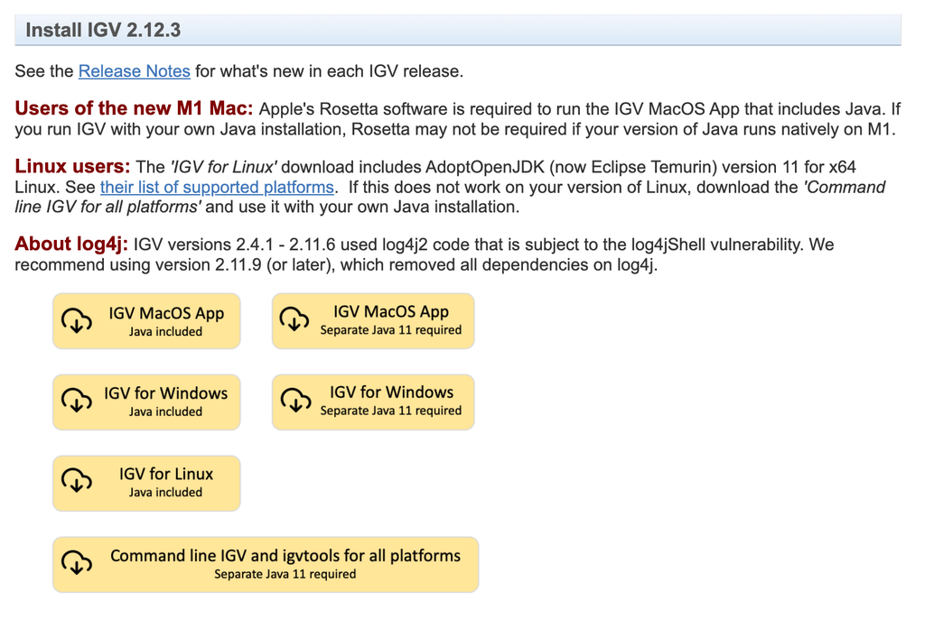

## 2. Open IGV

Download the correct reference, which in our case, is **Human (hg38)**. If you can’t see it on the list, click “More”.

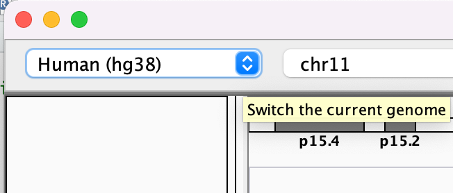

## 3. Load the BAM files into IGV

A set of alignments have been prepared for you, corresponding to 2 samples from our cancer bulk RNA dataset.

**Important**: You do not need to download these files. Simply copy the links and paste them into IGV as shown below.

HCT116_EpCAMhigh_1:

- https://fgcz-gstore.uzh.ch/public/KAIST_SS25/GSE154927_full/bams/HCT116_EpCAMhigh_1.bam
- https://fgcz-gstore.uzh.ch/public/KAIST_SS25/GSE154927_full/bams/HCT116_EpCAMhigh_1.bam.bai

HCT116_EpCAMlow_1

- https://fgcz-gstore.uzh.ch/public/KAIST_SS25/GSE154927_full/bams/HCT116_EpCAMlow_1.bam
- https://fgcz-gstore.uzh.ch/public/KAIST_SS25/GSE154927_full/bams/HCT116_EpCAMlow_1.bam.bai

#### Loading the files

[figure not shown]

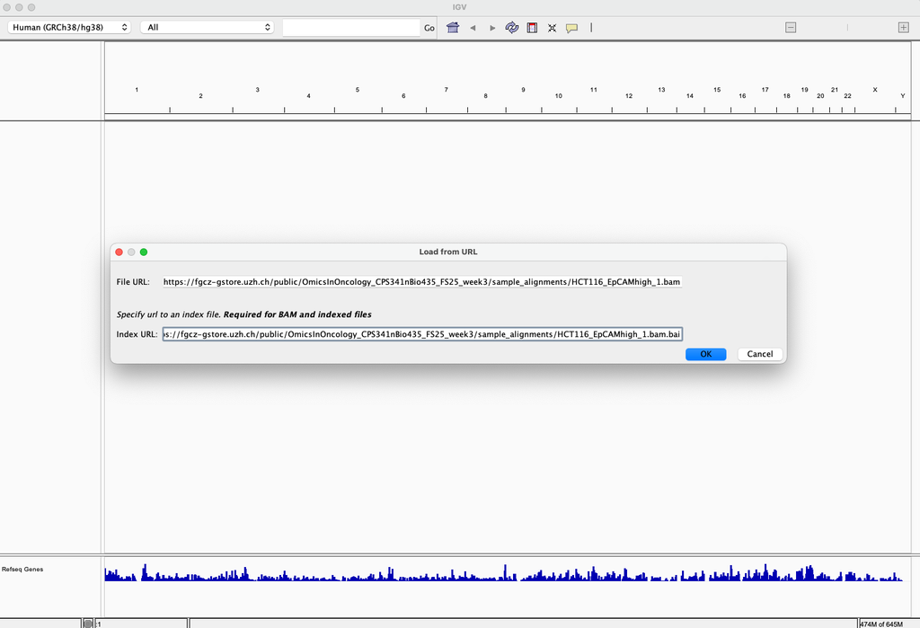

### Questions

Search for the gene `ESRP1` and take a look at the reads mapped to this gene.

- **Question 1**: What is the gene model? Do our reads map to the right part of the gene? (Hint: Take a look at the annotation track at the bottom)
- **Question 2**: Is the gene expressed in samples from both conditions?
- **Question 3**: Is there a difference in the read coverage between samples from both conditions? (Hint: Take a look at the number of reads in the coverage track)

Next, right click on the sample track, select `Sashimi Plot`, and then `OK` to include both samples.

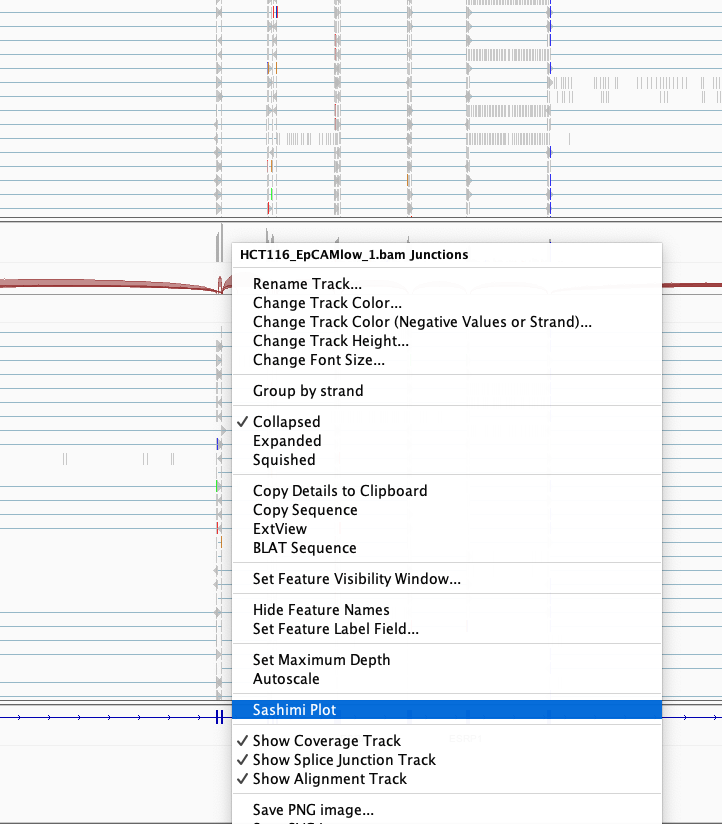

- **Question 4**: How many isoforms are identified?
- **Question 5**: Look at the splice junctions, which isoforms are present almost exclusively in one sample? Which sample?

## References

Dobin, Alexander, Carrie A. Davis, Felix Schlesinger, Jorg Drenkow, Chris Zaleski, Sonali Jha, Philippe Batut, Mark Chaisson, and Thomas R. Gingeras. 2012. “STAR: Ultrafast Universal RNA-Seq Aligner.” *Bioinformatics* 29 (1): 15–21. https://doi.org/10.1093/bioinformatics/bts635.